# Logistic Regression Diagnostics

Carrie Holt

January 15, 2021

# Assumptions of logistic regression

1. The relationship between aggregate abundance and logit(proportions) is linear
2. The observed proportions are independent (not autocorrelated)
3. There are no influential values (outliers)
4. There is no multicollinearity among predictors (NA, only 1 predictor)

# Steps:

1. Estimate Pearson resiudals and deviance residuals (Assumption 3). Are deviance residuals >2?
2. 1. Plot residuals against fitted values (Assumption 1). Is there a trend in residuals over fitted values?
2. Plot autocorrelation among residuals Assumption 2). Are residuals autocorrelated?
3. Evaluate statistical significance of model coefficients.
4. Evaluate Pearson Chi-squared statistic (goodness of fit). Is there statistical evidence for lack of fit?
5. Evaluate Deviance G-squared statistic (goodness of fit) Is there statistical evidence for lack of fit?
6. Evaluate quasi-Rsquared. What is the ratio of the fit to the null model?
7. Evaluate Wald test. Is deviance significantly reduced with the predictor, Aggregate abundance?
8. Evaluate hit rate. What is the classification accuracy of the LRP based on the logistic regression?

This code is wrapped inside a function LRdiagnostics() in a file of the same name. It’s extracted here for demonstration purposes.

## The arguments of the function are:

All_Ests = Dataframe containing parameters of logistic regression, B_0 and B_1 with p values (All_Ests <- data.frame(summary(sdreport(obj), p.value=TRUE)))

AggAbund = Vector of scaled observed aggregate abundances, with NAs removed

obsPpnAboveBM = Vectors of observed ppn of CUs above their lower benchmarks with NAs removed

p = the proportion of CUs that must be > their benchmark when defining LRP

nLL = negLogLikehood = ans from TMB file, outputted with REPORT(ans); in TMB and then called in R with obj$report()$ans

dir = name of directory where plots should be saved followed by /

plotname = filename for residual plots

First input data are loaded.

Step 1. What are residuals, and are deviance residuals > 2?

```r
load(here("RmdReports", "DataIn", "SR_IndivRicker_Surv_p0.8_2018.rda"))
All_Ests <- input$All_Ests
AggAbund <- input$AggAbund
obsPpnAboveBM <- input$obsPpnAboveBM
p <- input$p
nLL <- input$nLL
dir <- input$dir
plotname <- input$plotname

# Need a better way to source this relatively ...
source("C:/github/SalmonLRP_RetroEval/Code/helperFunctions.r")

#setwd(rmdDir)

 #-------------------------------------------------------------------------------
  # Step 1. Estimate Pearson resiudals and deviance residuals (Assumption 3).
  #   Are deviance residuals >2?
  #-------------------------------------------------------------------------------

  # Get observed and predicted ppn of CUs above their lower benchmark
  B_0 <- All_Ests %>% filter(Param=="B_0") %>% pull(Estimate)
  B_1 <- All_Ests %>% filter(Param=="B_1") %>% pull(Estimate)
  predPpnAboveBM <- inv_logit(B_0 + B_1*AggAbund)


  # Pearson residuals: Eq3.15 https://data.princeton.edu/wws509/notes/c3s8
  # setting n=1 (number of trials at each observation of x)

  PearResid <- ( obsPpnAboveBM - predPpnAboveBM ) / sqrt( predPpnAboveBM *
                                                            (1 - predPpnAboveBM) )

  PearResid
```

```
##  [1]  0.116128744 -0.858031283  0.220842736  0.001009125  0.002087121
##  [6]  0.246908702  0.016894613  0.327226801  0.082265977  0.001373749
## [11] -0.016196652  0.217978834  0.019947622  0.107602419  0.001945074
## [16]  0.001664671 -0.256851172 -0.298818742  0.001280254  0.167526565
## [21]  0.045841822
```

```r
  # Deviance residual: Eq3.16 https://data.princeton.edu/wws509/notes/c3s8
  # setting n=1 (number of trials at each observation of x)
  # To avoid NANs, use ifelse statement in the eqn, as suggested here:
  # https://www.datascienceblog.net/post/machine-learning/interpreting_
  # generalized_linear_models/#:~:text=For%20type%20%3D%20%22pearson%22%2
  # 0%2C,%CB%86f(xi)

  binom.resid <- function(y, mu) {
    y * log( ifelse(y== 0, 1, y/mu)) + (1-y) * log(
      ifelse(y==1 ,1,(1-y)/(1-mu) ) )
  }


  DevResid <- sign(obsPpnAboveBM - predPpnAboveBM ) *
    sqrt( 2 * binom.resid(y=obsPpnAboveBM, mu=predPpnAboveBM) )


  DevResid
```

```
##  [1]  0.163681154 -0.612543529  0.308608142  0.001427118  0.002951632
##  [6]  0.344028608  0.023890886  0.342702939  0.081667582  0.001942774
## [11] -0.016129888  0.304698129  0.028207391  0.151735066  0.002750748
## [16]  0.002354198 -0.236585472 -0.298137194  0.001810551  0.235280856
## [21]  0.064796105
```

```r
  # Observations with a deviance residual in excess of two may indicate
  # lack of fit. (https://data.princeton.edu/wws509/notes/c3s8)

  ## Testing. Residuals match output from R using glm objects
  # ModDat <- data.frame(xx=data$LM_Agg_Abund, yy=SMUlogisticData$ppn)
  # Fit_Mod <- glm( yy ~ xx , family = quasibinomial, data=ModDat)
  # B_0 <- Fit_Mod$coef[1]
  # B_1 <- Fit_Mod$coef[2]
  # obsPpnAboveBM <- ModDat$yy
  # predPpnAboveBM <- inv_logit(B_0 + B_1*ModDat$xx)
  # residuals(Fit_Mod, type="pearson")
  # residuals(Fit_Mod, type="deviance")
```

2. Then residuals are plotted. Is there a trends over fitted values?

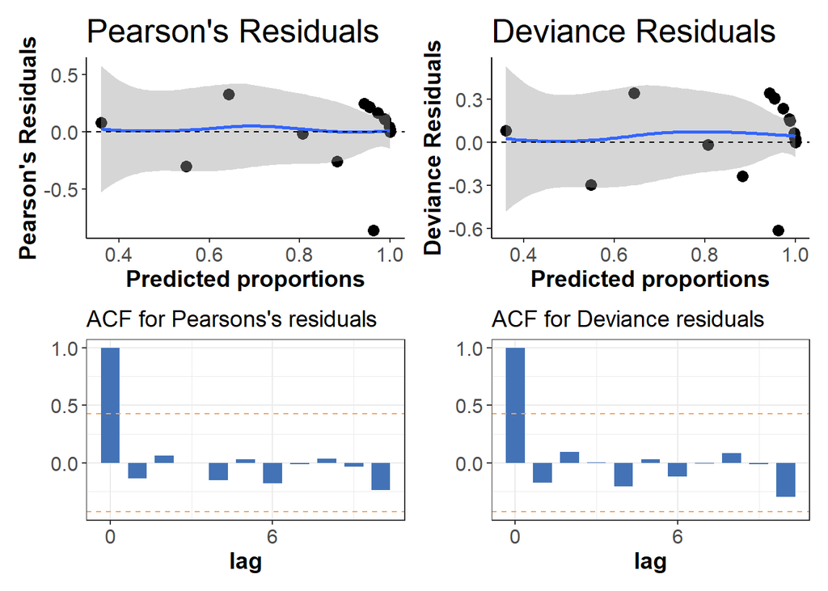

```r
  #-------------------------------------------------------------------------------
  # Step 2:
  # 2a. Plot residuals against fitted values (Assumption 1).
  #   Is there a trend in residuals over fitted values?
  # 2b. Plot autocorrelation among residuals Assumption 2).
  #   Are residuals autocorrelated?
  #-------------------------------------------------------------------------------


  # Put data for diagnostics in a dataframe for plotting
  diagData <- data.frame(predPppnAboveBM = predPpnAboveBM,
                         PearResid = PearResid, DevResid=DevResid)

  p1 <- ggplot(diagData, aes(predPpnAboveBM, PearResid)) +
    geom_point(size=3) +
    #geom_smooth(method="lm", formula=y~x) +
    geom_smooth(method="loess", formula=y~x, span=1) +
    geom_hline(linetype="dashed", yintercept=0) +
    xlab("Predicted proportions") + ylab("Pearson's Residuals") +
    ggtitle("Pearson's Residuals") +
    theme_classic() +
    theme(axis.text=element_text(size=12),
          axis.title=element_text(size=14,face="bold"),
          plot.title = element_text(size = 20)
    )

  p2 <- ggplot(diagData, aes(predPpnAboveBM, DevResid)) +
    geom_point(size=3) +
    #geom_smooth(method="lm", formula=y~x) +
    geom_smooth(method="loess", formula=y~x, span=1) +
    geom_hline(linetype="dashed", yintercept=0) +
    xlab("Predicted proportions") + ylab("Deviance Residuals") +
    ggtitle("Deviance Residuals") +
    theme_classic() +
    theme(axis.text=element_text(size=12),
          axis.title=element_text(size=14,face="bold"),
          plot.title = element_text(size = 20)
    )

  # See ggplot.cor function in "helperFunctions.r"
  p3 <- ggplot.corr(data=PearResid, title="Pearsons's residuals")
  p4 <- ggplot.corr(data=DevResid, title="Deviance residuals")

  p1+p2+p3+p4
```

3. Are coefficients significant?

```r
  #-------------------------------------------------------------------------------
  # step 3.
  # Evaluate statistical significance of model coefficients.
  #-------------------------------------------------------------------------------

  signTable <-  All_Ests %>% filter(Param %in% c("B_0", "B_1")) %>%
    rename(P.value=Pr...z.2..) %>% dplyr::select(Param, Estimate,
                                                 Std..Error, z.value,
                                                 P.value)

  signTable
```

```
##   Param   Estimate Std..Error   z.value      P.value
## 1   B_0 -3.2280120 1.35655406 -2.379568 0.0173329654
## 2   B_1  0.2747975 0.08343492  3.293555 0.0009892891
```

4. What is goodness of fit based on Pearson chi-square?

```r
 #-------------------------------------------------------------------------------
  # Step 4.
  # Evaluate Pearson Chi-square statistic (goodness of fit).
  #   Is there statistical evidence for lack of fit?
  #-------------------------------------------------------------------------------

  # Evaluate goodness of fit by comparing the residual deviance to a Chi-square
  # distribution

  # Sum of squared Pearson's residuals
  Pearson <- sum(PearResid^2)

  # Statistical test of the goodness of fit
  # Section 6.5.6. https://bookdown.org/roback/bookdown-bysh/ch-logreg.html
  # Section 1.4 of https://www.flutterbys.com.au/stats/tut/tut10.5a.html
  p.PearChiSq <- 1 - pchisq(q=Pearson, df=length(PearResid)-2)
  #values < 0.05 indicate statistically significant evidence for lack of fit
  names(p.PearChiSq) <- c("PearChiSq")
  p.PearChiSq
```

```
## PearChiSq
##         1
```

5. What is goodness of fit based on Deviance G-squared? This statistics measures the deviance of the fitted logistic model with respect to a perfect model (the saturated model)

```r
 #-------------------------------------------------------------------------------
  # Step 5.
  # Evaluate Deviance G-squared statistic (goodness of fit)
  #   Is there statistical evidence for lack of fit?
  #-------------------------------------------------------------------------------

  # Deviance statistic (sum of deviance residuals)
  # The deviance is a key concept in logistic regression. It measures the
  # deviance of the fitted logistic model with respect to a perfect model (the
  # saturated model) https://bookdown.org/egarpor/SSS2-UC3M/logreg-deviance.html
  Deviance <- sum(DevResid^2)
  p.DevChiSq <- 1-pchisq(q=Deviance, df=length(DevResid)-2)
  # values < 0.05 indicate statistically significant evidence for lack of fit
  # See section 6.5.6: https://bookdown.org/roback/bookdown-bysh/ch-logreg.html
  names(p.DevChiSq) <- c("p.DevChiSq")

  p.DevChiSq
```

```
## p.DevChiSq
##          1
```

6. What is quasiR2? This is not the percentage of variance explained by the logistic model, but rather a ratio indicating how close is the fit to being perfect or the worst.

```r
  #-------------------------------------------------------------------------------
  # Step 6.
  # Evaluate quasi-Rsquared.
  #   What is the ratio of the fit to the null model?
  #-------------------------------------------------------------------------------

  # What is ratio of fit to the null model? This is a measure of the
  # strength of the relationship
  NullDev <- deviance(glm( obsPpnAboveBM ~ 1 , family =
                             quasibinomial))
  quasiR2 <- 1 - Deviance/NullDev
  # This is not the percentage of variance explained by the logistic model,
  # but rather a ratio indicating how close is the fit to being perfect
  # or the worst. It is not related to any correlation coefficient
  # https://bookdown.org/egarpor/SSS2-UC3M/logreg-deviance.html
  # Interpretation:
  #   1) Should be a quantity between 0 and 1
  #   2) If the fit is perfect, then R2 = 1
  #   3) If the predictors do not add anything to the regression, then R2=0

  names(quasiR2) <- c("quasiR2")

  quasiR2
```

```
##   quasiR2
## 0.8370059
```

```r
  pchisq(q=(Deviance-NullDev), df=1)
```

```
## [1] 0
```

7. Wald test

```r
#-------------------------------------------------------------------------------
  # Step 7.
  # Evaluate Wald test
  #   Is the predictor, 'Aggregate Abundance', a significant predictor of the ppn
  #   of CUs > their lower benchmark?
  #-------------------------------------------------------------------------------

  # The Wald test evaluates the significance of a predictor based on difference
  # in Deviances between the specificed model and a reduced model without the
  # predictor
  # See Section 4.7 https://bookdown.org/egarpor/SSS2-UC3M/logreg-deviance.html
  p.Wald <- signif( pchisq(q=(Deviance-NullDev), df=1), digits=2)
  names(p.Wald) <- c("p.Wald")
  p.Wald
```

```
## p.Wald
##      0
```

8. What is the classifiation accuracy?

```r
 #-------------------------------------------------------------------------------
  # Step 8.
  # Evaluate hit rate from a confusion matrix
  #   What is the classification accuracy of the LRP based on the logistic
  #   regression?
  #-------------------------------------------------------------------------------


  # In which years did the model predict aggregate abundances >LRP?
  yHat <- predPpnAboveBM > p
  # In which years were observed aggregate abundances >LRP?
  y <- obsPpnAboveBM > p

  # Confusion Matrix
  confMat <- table(y, yHat)
  confMat
```

```
##        yHat
## y       FALSE TRUE
##   FALSE     3    3
##   TRUE      0   15
```

```r
  # What is the accuracy in classifying observed aggregate abundances?
  # Hit ratio = ratio of correct classification
  hitRatio <- sum(diag(confMat))/sum(confMat)
  hitRatio <- round(hitRatio, digits=2)
  names(hitRatio) <- c("hitRatio")
  hitRatio
```

```
## hitRatio
##     0.86
```